# imaging the influence of certainty and value on spatial attention - (second) pilot data analysis

Kelly Garner - 28 June 2019

> Initial analysis of the behavioural data collected on a simple paradigm where simple cues (e.g. square, triangle, circle) probabilistically predict the upcoming target location (gabor oriented clockwise or counterclockwise) and the reward value available should the participant got the target correct. [All data was collected using this code](https://github.com/kel-github/imaging-cert-reward-att-task-code/tree/master/pilot_expCues).

# Get the data

Starting by loading *libraries*.

```r
library(rmarkdown)    # You need this library to run this template.
library(epuRate)
#library(tidyverse)
library(tidyr)
library(dplyr)
library(cowplot)
library(ggplot2)
library(readr)
library(wesanderson)
#library(rjson)
library(RJSONIO)
source("R_rainclouds.R") # for the raincloud plot
```

Hidden code below defines plotting functions.

```r
line.plot <- function(data, dv, iv, grp, ylims, cols){
          ggplot(data, aes_string(x=iv, y=dv, col=grp)) +
            geom_line(aes_string(group=grp), size=1.1) + geom_point() +
            facet_wrap(~sub, nrow=1) +
            scale_fill_manual(values=cols) +
            scale_color_manual(values=cols) +
            ylab(dv) + xlab(iv) + ylim(ylims) +
            theme(panel.border = element_blank(),
                  panel.grid.major =   element_blank(),
            panel.grid.minor = element_blank(),
            axis.line = element_line(colour = "black"))
}
```

Here is the behavioural data in longform. Key to data: sub = subject number, sess = session number, t = trial, rew = cue value, loc = target location, cue = shape, co1/co2 = contrast of the target on left and right, or = orientation (0 = anti, 1 = clockwise) response = correct (1) or incorrect (0), rt = RT, rew_tot = reward value accrued, cert = probability of target location, given the cue

```r
get_participant_data <- function(subjects, sessions, data_path) {
  # this function loads each participant's data
  # and concatenates them into a longform dataset
  fn <- 'sub-0%d_ses-%d_task-learn-att-v1-test-v1_events.tsv'
  get_subject_strings <- function(i) {
    get_session_strings <- function(j) dir(sprintf(paste(data_path, "sub-0%d_ses-%d_task-learn-att-v1", sep = "/"), i, j), pattern=sprintf(fn, i, j), full.names = TRUE)
    do.call(cbind, lapply(sessions, get_session_strings))
  }
  files <- do.call(rbind, lapply(subjects, get_subject_strings))
  rownames(files) <- subjects
  colnames(files) <- sessions
  resplog <- function(i, j) read.table(files[as.character(i),as.character(j)], sep = "\t", header = TRUE)
  d <- do.call(rbind, lapply(subjects, function(i) do.call(rbind, lapply(sessions, function (j) resplog(i, j)))))

  # get trials to getthe reward condition
  fn <- 'sub-0%d_ses-%d_task-learn-att-v1-test-v1_trls.csv'
  files <- do.call(rbind, lapply(subjects, get_subject_strings))
  rownames(files) <- subjects
  colnames(files) <- sessions
  eventlog <- function(i, j) {
    e = read.table(files[as.character(i),as.character(j)], sep = ",", header = TRUE)
    e$sub = i
    e$sess= j
    e
  }
  e <- do.call(rbind, lapply(subjects, function(i) do.call(rbind, lapply(sessions, function (j) eventlog(i, j)))))
  names(e)[1] = "t"
  e <- e[, -c(2, 4:8 )]
  d <- inner_join(d, e, by=c("sub", "sess", "t"))
  # ALLOCATE CUES
  # 1 = left arrow, 2 = right arrow, 3 = bidirectional arrow
  d$cert <- NA
  d$cert[ d$loc == 1 & d$cue == 1 ] = ".8"
  d$cert[ d$loc == 2 & d$cue == 1 ] = ".2"
  d$cert[ d$loc == 2 & d$cue == 2 ] = ".8"
  d$cert[ d$loc == 1 & d$cue == 2 ] = ".2"
  d$cert[ d$cue == 3 ] = ".5"
  d$cert <- as.factor(d$cert)

  d$loc <- as.factor(d$loc)
  levels(d$loc) <- c("left", "right")
  d$sub <- as.factor(d$sub)
  d$rew <- as.factor(d$rew)
  levels(d$rew) <- c("0", "50")
  d$reward_type <- as.factor(d$reward_type)
  levels(d$reward_type) <- c("htgt/hdst", "htgt/ldst", "ltgt/ldst", "ltgt/hdst")

  d <- d %>% filter(t > 120) # get rid of the first block of trials

  d
}

subjects = c(1, 2, 3)
sessions = 1
data_path = "~/Dropbox/MC-Projects/imaging-value-cert-att/pilot_data/pilot_expCues"
raw.data <- get_participant_data(subjects, sessions, data_path)

# Show it:
raw.data %>% head(5)
```

|  | sub | sess | t | rew | loc | cue | co1 | co2 | or | resp | rt | rew_tot | reward_type | cert |
| --- | --- | --- | --- | --- | --- | --- | --- | --- | --- | --- | --- | --- | --- | --- |
| 1 | 1 | 1 | 121 | 50 | left | 2 | 0.437 | 0.3106 | 1 | 1 | 0.687 | 66 | htgt/ldst | .2 |
| 2 | 1 | 1 | 122 | 0 | right | 1 | 0.437 | 0.3106 | 1 | 1 | 1.061 | 5 | ltgt/hdst | .2 |
| 3 | 1 | 1 | 123 | 0 | right | 3 | 0.437 | 0.3106 | 0 | 1 | 0.576 | 8 | ltgt/ldst | .5 |
| 4 | 1 | 1 | 124 | 50 | left | 3 | 0.437 | 0.3106 | 1 | 0 | 0.669 | 0 | htgt/ldst | .5 |
| 5 | 1 | 1 | 125 | 0 | right | 3 | 0.437 | 0.3106 | 0 | 1 | 0.610 | 7 | ltgt/ldst | .5 |

# Overview of individual subject data

```r
get.sub.data <- function(subject, data, sd_reject=2.5, RT_min=0.1){
  # this function takes the subject index (defined in the variable subject)
  # and all the raw data
  # it filters the data to get the individual subject's data, then trims to
  # get the correct RTs that are > .1 s, and are < 3 * sd from the median
  # for each certainty and reward condition
  sub.data <- data %>% filter(sub == subject)
  sub.data <- sub.data %>%
                filter(rt > RT_min) %>%
                filter(resp == 1) %>%
                group_by(cert, reward_type) %>%
                filter(rt < median(rt) + sd_reject*sd(rt))
}
# apply the function defined above across subjects, put
# results into a single dataframe
subjects = c("1", "2", "3")
sub.data <- lapply(subjects, get.sub.data, data = raw.data)
sub.data <- do.call(rbind, sub.data)
```

## summary plots

To better visualise the influence of certainty and value, I now show 1) the mean RT for each cue x value condition, and 2) the inverse efficiency score (RT/accuracy, see [Gould et al, 2011](https://www.physiology.org/doi/full/10.1152/jn.00653.2010?url_ver=Z39.88-2003&rfr_id=ori%3Arid%3Acrossref.org&rfr_dat=cr_pub%3Dpubmed&))for each participant.

First, the summary measures are computed (see code chunk for details), and the mean RT is plotted for each subject (panels) across the location probability conditions, for the value conditions.

```r
# first I do a bit of data wrangling to summarise the data, and then define plotting functions,
# then I will plot accuracy in this code panel, then the bias score, and then inverse efficiency
acc.data = raw.data %>% group_by(sub, reward_type, cert) %>%
            summarise(acc = mean(resp))
sum.inv.eff = sub.data %>% group_by(sub, reward_type, cert) %>%
              summarise(medRT = mean(rt)) %>%
              inner_join(acc.data, sum.inv.eff, by=c("sub", "reward_type", "cert")) %>%
              transform(inv_eff = medRT/acc)
```

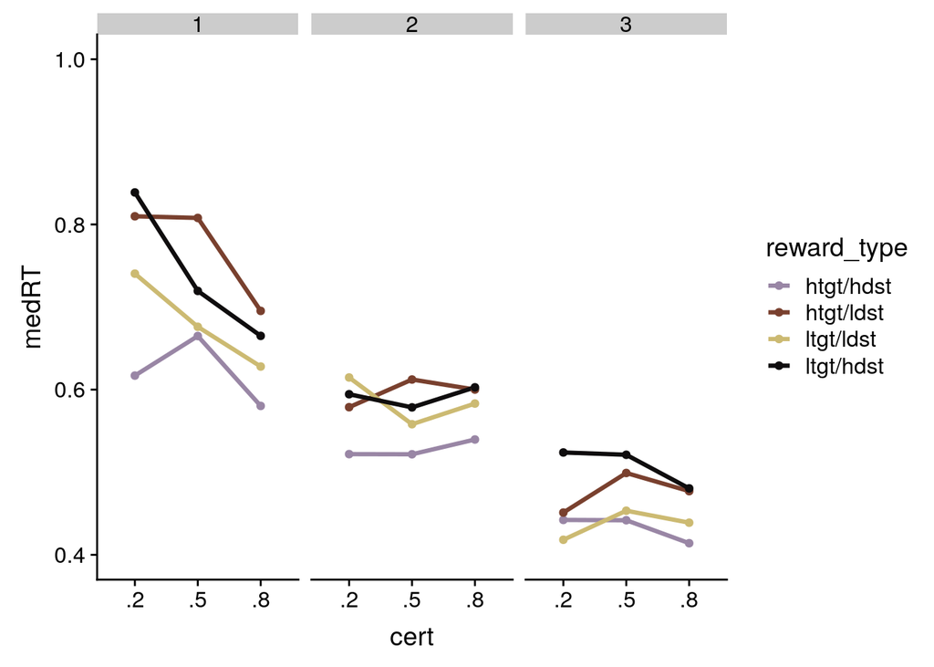

```r
line.plot(sum.inv.eff, dv="medRT", iv="cert", grp="reward_type", ylims =c(0.4, 1), cols = wes_palette("IsleofDogs1"))
```

Now we plot inverse efficiency data (Median RT/Acc), again according to the same conventions.

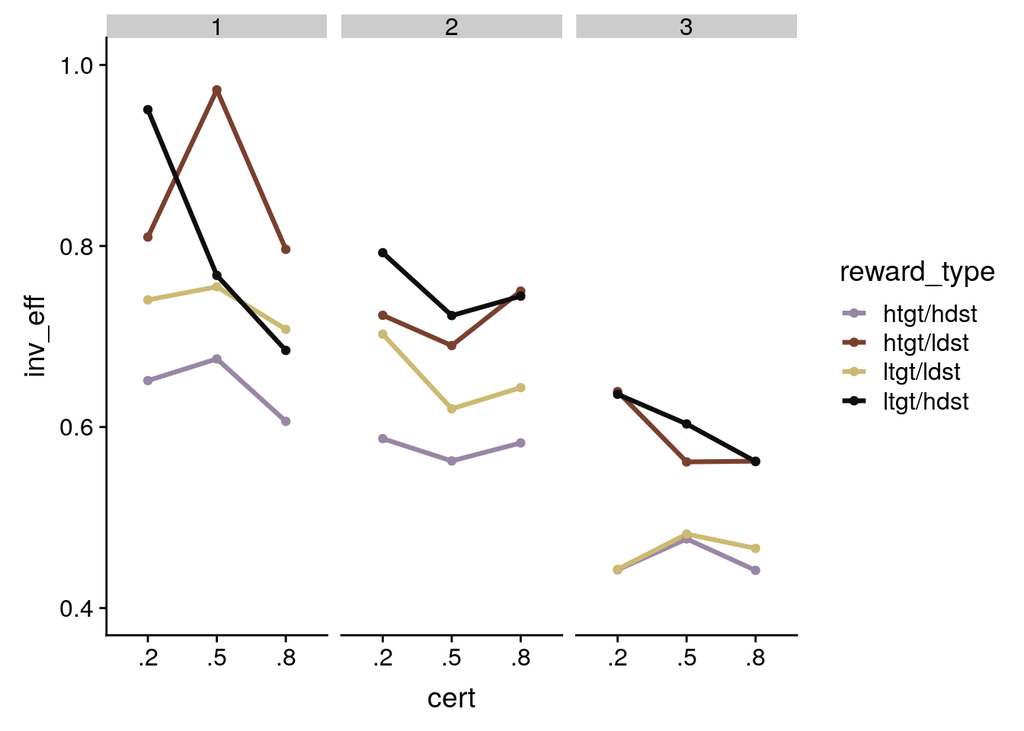

```r
# Inverse efficiency plot
line.plot(sum.inv.eff, dv="inv_eff", iv="cert", grp="reward_type", ylims =c(0.4, 1), cols = wes_palette("IsleofDogs1"))
```

Now look at the N of 3 average

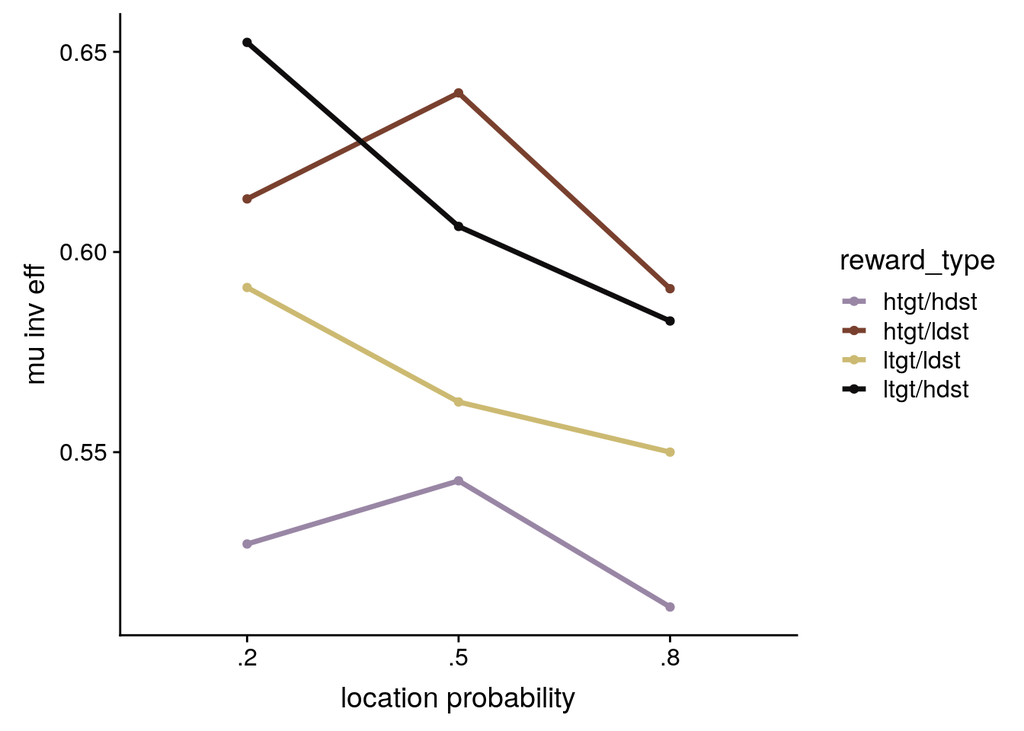

```r
# summarise inverse efficiency over subs
gmu.inv.eff = sum.inv.eff %>% group_by(reward_type, cert) %>%
              summarise( mu.inv.eff = mean( medRT ))

ggplot(gmu.inv.eff, aes_string(x="cert", y="mu.inv.eff", col="reward_type")) +
            geom_line(aes(group=reward_type), size=1.2) + geom_point() +
            scale_fill_manual(values=wes_palette("IsleofDogs1")) +
            scale_color_manual(values=wes_palette("IsleofDogs1")) +
            ylab("mu inv eff") + xlab("location probability") +
            theme(panel.border = element_blank(),
                  panel.grid.major =   element_blank(),
            panel.grid.minor = element_blank(),
            axis.line = element_line(colour = "black"))
```

Now for each participant, I analyse their individual RT data with trial as a regressor. Those with a main effect of probability and value will be retained for the MRI session

```r
sub.model <- function(data, csub){
  data = data %>% filter(sub == csub)
  mod <- with(data, aov( rt ~ cert*reward_type+Error(factor(t)) ))
  mod
}

incls = lapply( unique(sub.data$sub), sub.model, data = sub.data  )
lapply(as.numeric(unique(sub.data$sub)), function(x) summary(incls[[x]]))
```

```
## [[1]]
##
## Error: factor(t)
##                   Df Sum Sq Mean Sq F value   Pr(>F)
## cert               2  0.867  0.4333   16.45 1.18e-07 ***
## reward_type        3  1.372  0.4574   17.36 9.32e-11 ***
## cert:reward_type   6  0.243  0.0406    1.54    0.163
## Residuals        520 13.699  0.0263
## ---
## Signif. codes:  0 '***' 0.001 '**' 0.01 '*' 0.05 '.' 0.1 ' ' 1
##
## [[2]]
##
## Error: factor(t)
##                   Df Sum Sq Mean Sq F value   Pr(>F)
## cert               2  0.017 0.00873   0.652    0.521
## reward_type        3  0.417 0.13904  10.385 1.23e-06 ***
## cert:reward_type   6  0.060 0.00996   0.744    0.614
## Residuals        492  6.587 0.01339
## ---
## Signif. codes:  0 '***' 0.001 '**' 0.01 '*' 0.05 '.' 0.1 ' ' 1
##
## [[3]]
##
## Error: factor(t)
##                   Df Sum Sq Mean Sq F value   Pr(>F)
## cert               2  0.076 0.03821   3.426   0.0333 *
## reward_type        3  0.456 0.15202  13.631 1.46e-08 ***
## cert:reward_type   6  0.042 0.00702   0.629   0.7071
## Residuals        501  5.588 0.01115
## ---
## Signif. codes:  0 '***' 0.001 '**' 0.01 '*' 0.05 '.' 0.1 ' ' 1
```

Therefore according to this criteria we would keep subjects 1 & 3.

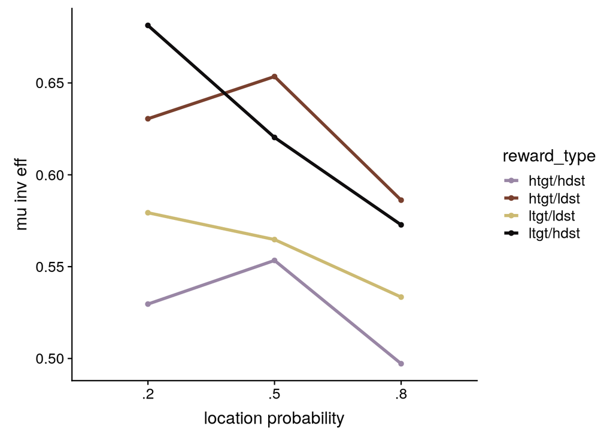

```r
# summarise inverse efficiency over subs
gmu.inv.eff = sum.inv.eff %>% filter(sub != "2") %>%
              group_by(reward_type, cert) %>%
              summarise( mu.inv.eff = mean( medRT ))

ggplot(gmu.inv.eff, aes_string(x="cert", y="mu.inv.eff", col="reward_type")) +
            geom_line(aes(group=reward_type), size=1.2) + geom_point() +
            scale_fill_manual(values=wes_palette("IsleofDogs1")) +
            scale_color_manual(values=wes_palette("IsleofDogs1")) +
            ylab("mu inv eff") + xlab("location probability") +
            theme(panel.border = element_blank(),
                  panel.grid.major =   element_blank(),
            panel.grid.minor = element_blank(),
            axis.line = element_line(colour = "black"))
```

A work by [Kelly Garner](https://github.com/kel-github)

*getkellygarner@gmail.com*